# 탐색적 데이터 분석(EDA)

### 3번째 발표 : 대중교통 이용량과 코로나19, 코로나19와 날씨 간의 상관관계 분석

- 작성자 : 임국정

## 1. 문제 정의

- 분석 목적 :
  - 1) 신종 코로나바이러스 감염증(코로나19)이 우리 생활에 미친 영향은 어느 정도일까?
  - 2) 코로나19와 같은 전 세계적 재난에 대응할 수 있는 방법은 무엇이 있을까?
- 가설 수립 :
  - 1) 코로나19가 확산할수록 대중교통 이용량은 감소했을 것이다.
  - 2) 날씨가 더워질수록 코로나19 확산세가 감소할 것이다.
    - 겨울에서 여름이 다가올수록 코로나19 확진자 수가 줄어들 것이다.
    - 온도가 높은 지역일수록 코로나19 확진자 수가 적을 것이다.(북반구, 남반구 비교)

## 2. 데이터 수집

- 서울 열린 데이터 광장 : 서울시 지하철호선별 역별 승하차 인원 정보
  - 교통카드(선후불교통카드 및 1회용 교통카드) 이용한 지하철호선별 역별(서울교통공사, 한국철도공사, 공항철도, 9호선) 승하차 인원 정보(일 단위).
- KAGGLE : Weather Data for COVID-19 Data Analysis
  - https://www.kaggle.com/davidbnn92/weather-data-for-covid19-data-analysis

## 3. 데이터 처리

### 3-1) 대중교통(지하철) 이용량과 코로나19 간의 상관관계 분석 위한 전처리

### 대중교통(지하철) CSV 파일 로드

```python
import warnings
warnings.filterwarnings(action='ignore')

subway1 = pd.read_csv("CARD_SUBWAY_MONTH_202001.csv", encoding="euc-kr", index_col=False)
subway2 = pd.read_csv("CARD_SUBWAY_MONTH_202002.csv")
subway3 = pd.read_csv("CARD_SUBWAY_MONTH_202003.csv")
subway1.head(3)
```

|  | 사용일자 | 노선명 | 역ID | 역명 | 승차총승객수 | 하차총승객수 | 등록일자 |
| --- | --- | --- | --- | --- | --- | --- | --- |
| 0 | 20200101 | 1호선 | 152 | 종각 | 20427.0 | 16301.0 | 20200104 |
| 1 | 20200101 | 1호선 | 151 | 시청 | 12126.0 | 10516.0 | 20200104 |
| 2 | 20200101 | 우이신설선 | 4713 | 신설동 | 892.0 | 828.0 | 20200104 |

### 1월 승하차총객수

```python
subway1_gangnam = subway1[["사용일자", "승차총승객수", "하차총승객수"]][subway1["역명"] == "강남"]
subway1_gangnam.head(3)
```

|  | 사용일자 | 승차총승객수 | 하차총승객수 |
| --- | --- | --- | --- |
| 560 | 20200101 | 39231.0 | 36768.0 |
| 621 | 20200102 | 115263.0 | 116820.0 |
| 1218 | 20200103 | 126036.0 | 132511.0 |

### 2월 승하차총객수

```python
subway2_gangnam = subway2[["사용일자", "승차총승객수", "하차총승객수"]][subway2["역명"] == "강남"]
subway2_gangnam.head(3)
```

|  | 사용일자 | 승차총승객수 | 하차총승객수 |
| --- | --- | --- | --- |
| 557 | 20200201 | 65598 | 69156 |
| 707 | 20200202 | 37382 | 36531 |
| 1764 | 20200203 | 100352 | 101584 |

### 3월 승하차총객수

```python
subway3_gangnam = subway3[["사용일자", "승차총승객수", "하차총승객수"]][subway3["역명"] == "강남"]
subway3_gangnam.head(3)
```

|  | 사용일자 | 승차총승객수 | 하차총승객수 |
| --- | --- | --- | --- |
| 101 | 20200301 | 18405 | 18248 |
| 1125 | 20200302 | 62556 | 63127 |
| 1738 | 20200303 | 62742 | 63287 |

### append 사용해 1~3월 승하차총객수 합침

```python
subway_result = subway1_gangnam.append((subway2_gangnam, subway3_gangnam), ignore_index=True)
subway_result["사용일자"] = subway_result["사용일자"].astype("str")
subway_result.rename(columns={"사용일자":"일자"}, inplace=True)
subway_result["승차총승객수"] = subway_result["승차총승객수"].astype("int")
subway_result["하차총승객수"] = subway_result["하차총승객수"].astype("int")
subway_result
```

|  | 일자 | 승차총승객수 | 하차총승객수 |
| --- | --- | --- | --- |
| 0 | 20200101 | 39231 | 36768 |
| 1 | 20200102 | 115263 | 116820 |
| 2 | 20200103 | 126036 | 132511 |
| 3 | 20200104 | 87333 | 93257 |
| 4 | 20200105 | 52620 | 51683 |
| ... | ... | ... | ... |
| 86 | 20200327 | 80402 | 82183 |
| 87 | 20200328 | 46628 | 48851 |
| 88 | 20200329 | 25275 | 24989 |
| 89 | 20200330 | 73778 | 74047 |
| 90 | 20200331 | 73891 | 74418 |

91 rows × 3 columns

### 1월부터 3월까지 강남역 지하철 일자별 승하차승객수 변화

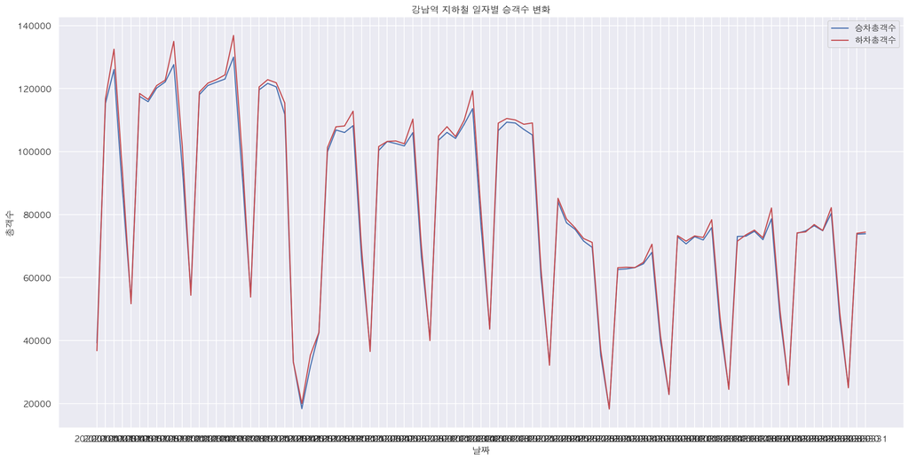

```python
x = subway_result["일자"]
y = subway_result["승차총승객수"]
y2 = subway_result["하차총승객수"]

plt.figure(figsize=(20,10))
plt.plot(x, y, 'b', label = "승차총객수")
plt.plot(x, y2, 'r', label = "하차총객수")
plt.title('강남역 지하철 일자별 승객수 변화')
plt.xlabel('날짜')
plt.ylabel('총객수')
plt.legend(loc="upper right")
plt.show()
```

- 승차총객수와 하차총객수의 움직임이 거의 같다는 사실을 확인할 수 있다.

### 3-2) 코로나19와 날씨 간의 상관관계 분석 위한 전처리

### 코로나-날씨 CSV 파일 로드

```python
covid19 = pd.read_csv("covid19_weather.csv")
covid19["ConfirmedCases"] = covid19["ConfirmedCases"].astype("int")
covid19["Fatalities"] = covid19["Fatalities"].astype("int")
covid19
```

|  | Id | Country_Region | Province_State | Date | ConfirmedCases | Fatalities | country+province | Lat | Long | day_from_jan_first | ... | min | max | stp | slp | dewp | rh | ah | wdsp | prcp | fog |
| --- | --- | --- | --- | --- | --- | --- | --- | --- | --- | --- | --- | --- | --- | --- | --- | --- | --- | --- | --- | --- | --- |
| 0 | 1 | Afghanistan | NaN | 2020-01-22 | 0 | 0 | Afghanistan- | 33.000000 | 65.000000 | 22 | ... | 33.6 | 54.9 | 999.9 | 1024.3 | 27.4 | 0.545709 | 0.186448 | 9.4 | 0.00 | 0 |
| 1 | 2 | Afghanistan | NaN | 2020-01-23 | 0 | 0 | Afghanistan- | 33.000000 | 65.000000 | 23 | ... | 32.7 | 55.9 | 999.9 | 1020.8 | 22.8 | 0.461259 | 0.163225 | 14.9 | 99.99 | 1 |
| 2 | 3 | Afghanistan | NaN | 2020-01-24 | 0 | 0 | Afghanistan- | 33.000000 | 65.000000 | 24 | ... | 36.9 | 43.2 | 999.9 | 1018.6 | 34.5 | 0.801794 | 0.325375 | 10.4 | 0.17 | 1 |
| 3 | 4 | Afghanistan | NaN | 2020-01-25 | 0 | 0 | Afghanistan- | 33.000000 | 65.000000 | 25 | ... | 37.9 | 56.3 | 999.9 | 1018.0 | 37.8 | 0.728175 | 0.214562 | 6.1 | 0.57 | 1 |
| 4 | 5 | Afghanistan | NaN | 2020-01-26 | 0 | 0 | Afghanistan- | 33.000000 | 65.000000 | 26 | ... | 36.1 | 53.1 | 999.9 | 1014.8 | 33.2 | 0.685513 | 0.231656 | 10.8 | 0.00 | 1 |
| ... | ... | ... | ... | ... | ... | ... | ... | ... | ... | ... | ... | ... | ... | ... | ... | ... | ... | ... | ... | ... | ... |
| 24409 | 35642 | Zimbabwe | NaN | 2020-04-04 | 9 | 1 | Zimbabwe- | -17.829167 | 31.052222 | 95 | ... | 66.2 | 80.6 | 999.9 | NaN | 53.9 | 0.481730 | 0.130122 | 4.2 | 0.00 | 0 |
| 24410 | 35643 | Zimbabwe | NaN | 2020-04-05 | 9 | 1 | Zimbabwe- | -17.829167 | 31.052222 | 96 | ... | 66.2 | 80.6 | 999.9 | NaN | 53.9 | 0.481730 | 0.130122 | 4.2 | 0.00 | 0 |
| 24411 | 35644 | Zimbabwe | NaN | 2020-04-06 | 10 | 1 | Zimbabwe- | -17.829167 | 31.052222 | 97 | ... | 66.2 | 80.6 | 999.9 | NaN | 53.9 | 0.481730 | 0.130122 | 4.2 | 0.00 | 0 |
| 24412 | 35645 | Zimbabwe | NaN | 2020-04-07 | 11 | 2 | Zimbabwe- | -17.829167 | 31.052222 | 98 | ... | 66.2 | 80.6 | 999.9 | NaN | 53.9 | 0.481730 | 0.130122 | 4.2 | 0.00 | 0 |
| 24413 | 35646 | Zimbabwe | NaN | 2020-04-08 | 11 | 3 | Zimbabwe- | -17.829167 | 31.052222 | 99 | ... | 66.2 | 80.6 | 999.9 | NaN | 53.9 | 0.481730 | 0.130122 | 4.2 | 0.00 | 0 |

24414 rows × 21 columns

### 사용할 컬럼만 남기고 삭제

```python
covid19_df = covid19[["Country_Region", "Date", "ConfirmedCases", "Fatalities", "Lat", "Long", "temp", "min", "max"]]
covid19_df
```

|  | Country_Region | Date | ConfirmedCases | Fatalities | Lat | Long | temp | min | max |
| --- | --- | --- | --- | --- | --- | --- | --- | --- | --- |
| 0 | Afghanistan | 2020-01-22 | 0 | 0 | 33.000000 | 65.000000 | 42.6 | 33.6 | 54.9 |
| 1 | Afghanistan | 2020-01-23 | 0 | 0 | 33.000000 | 65.000000 | 42.0 | 32.7 | 55.9 |
| 2 | Afghanistan | 2020-01-24 | 0 | 0 | 33.000000 | 65.000000 | 40.1 | 36.9 | 43.2 |
| 3 | Afghanistan | 2020-01-25 | 0 | 0 | 33.000000 | 65.000000 | 46.0 | 37.9 | 56.3 |
| 4 | Afghanistan | 2020-01-26 | 0 | 0 | 33.000000 | 65.000000 | 42.8 | 36.1 | 53.1 |
| ... | ... | ... | ... | ... | ... | ... | ... | ... | ... |
| 24409 | Zimbabwe | 2020-04-04 | 9 | 1 | -17.829167 | 31.052222 | 74.6 | 66.2 | 80.6 |
| 24410 | Zimbabwe | 2020-04-05 | 9 | 1 | -17.829167 | 31.052222 | 74.6 | 66.2 | 80.6 |
| 24411 | Zimbabwe | 2020-04-06 | 10 | 1 | -17.829167 | 31.052222 | 74.6 | 66.2 | 80.6 |
| 24412 | Zimbabwe | 2020-04-07 | 11 | 2 | -17.829167 | 31.052222 | 74.6 | 66.2 | 80.6 |
| 24413 | Zimbabwe | 2020-04-08 | 11 | 3 | -17.829167 | 31.052222 | 74.6 | 66.2 | 80.6 |

24414 rows × 9 columns

### 향후 지하철 파일과의 머지를 위해 정규표현식 활용해 코로나19 파일 '일자'에서 '-' 제거

```python
covid19_df["Date"] = covid19_df["Date"].str.replace(pat=r'[^A-Za-z0-9]', repl=r'', regex=True)
covid19_df.rename(columns={"Date":"일자"}, inplace=True)
covid19_df
```

|  | Country_Region | 일자 | ConfirmedCases | Fatalities | Lat | Long | temp | min | max |
| --- | --- | --- | --- | --- | --- | --- | --- | --- | --- |
| 0 | Afghanistan | 20200122 | 0 | 0 | 33.000000 | 65.000000 | 42.6 | 33.6 | 54.9 |
| 1 | Afghanistan | 20200123 | 0 | 0 | 33.000000 | 65.000000 | 42.0 | 32.7 | 55.9 |
| 2 | Afghanistan | 20200124 | 0 | 0 | 33.000000 | 65.000000 | 40.1 | 36.9 | 43.2 |
| 3 | Afghanistan | 20200125 | 0 | 0 | 33.000000 | 65.000000 | 46.0 | 37.9 | 56.3 |
| 4 | Afghanistan | 20200126 | 0 | 0 | 33.000000 | 65.000000 | 42.8 | 36.1 | 53.1 |
| ... | ... | ... | ... | ... | ... | ... | ... | ... | ... |
| 24409 | Zimbabwe | 20200404 | 9 | 1 | -17.829167 | 31.052222 | 74.6 | 66.2 | 80.6 |
| 24410 | Zimbabwe | 20200405 | 9 | 1 | -17.829167 | 31.052222 | 74.6 | 66.2 | 80.6 |
| 24411 | Zimbabwe | 20200406 | 10 | 1 | -17.829167 | 31.052222 | 74.6 | 66.2 | 80.6 |
| 24412 | Zimbabwe | 20200407 | 11 | 2 | -17.829167 | 31.052222 | 74.6 | 66.2 | 80.6 |
| 24413 | Zimbabwe | 20200408 | 11 | 3 | -17.829167 | 31.052222 | 74.6 | 66.2 | 80.6 |

24414 rows × 9 columns

### 총 국가 수 : 184개국

```python
df_country = covid19_df.groupby(["Country_Region"]).size().reset_index(name="counts")
df_country.head(5)
```

|  | Country_Region | counts |
| --- | --- | --- |
| 0 | Afghanistan | 78 |
| 1 | Albania | 78 |
| 2 | Algeria | 78 |
| 3 | Andorra | 78 |
| 4 | Angola | 78 |

### 2020-1-22부터 2020-04-08까지 국가별 누적 확진자, 사망자 수

```python
df_country_total = covid19_df[['Country_Region', 'ConfirmedCases', 'Fatalities', 'Lat', 'Long']][covid19_df.일자 == '20200408'].reset_index(drop=True)
df_country_total.head(5)
```

|  | Country_Region | ConfirmedCases | Fatalities | Lat | Long |
| --- | --- | --- | --- | --- | --- |
| 0 | Afghanistan | 444 | 14 | 33.000000 | 65.0000 |
| 1 | Albania | 400 | 22 | 41.153300 | 20.1683 |
| 2 | Algeria | 1572 | 205 | 28.033900 | 1.6596 |
| 3 | Andorra | 564 | 23 | 42.506300 | 1.5218 |
| 4 | Angola | 19 | 2 | -8.830833 | 13.2450 |

### 일자별 확진자 수 변화

```python
df_date_confirmedcase = covid19_df.groupby(['일자']).sum()["ConfirmedCases"].reset_index()
df_date_confirmedcase
```

|  | 일자 | ConfirmedCases |
| --- | --- | --- |
| 0 | 20200122 | 554 |
| 1 | 20200123 | 653 |
| 2 | 20200124 | 939 |
| 3 | 20200125 | 1432 |
| 4 | 20200126 | 2113 |
| ... | ... | ... |
| 73 | 20200404 | 1197232 |
| 74 | 20200405 | 1271942 |
| 75 | 20200406 | 1344928 |
| 76 | 20200407 | 1425923 |
| 77 | 20200408 | 1510928 |

78 rows × 2 columns

### 일자별 사망자 수 변화

```python
df_date_fatalities = covid19_df.groupby(['일자']).sum()["Fatalities"].reset_index()
df_date_fatalities
```

|  | 일자 | Fatalities |
| --- | --- | --- |
| 0 | 20200122 | 17 |
| 1 | 20200123 | 18 |
| 2 | 20200124 | 26 |
| 3 | 20200125 | 42 |
| 4 | 20200126 | 56 |
| ... | ... | ... |
| 73 | 20200404 | 64601 |
| 74 | 20200405 | 69369 |
| 75 | 20200406 | 74560 |
| 76 | 20200407 | 81859 |
| 77 | 20200408 | 88332 |

78 rows × 2 columns

### 일자별 전 세계 확진자, 사망자 수 변화 그래프

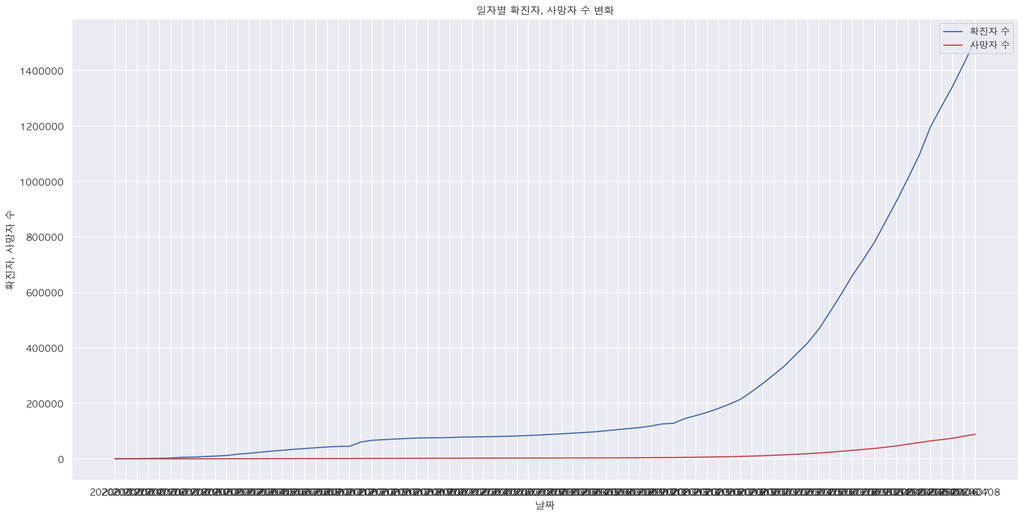

```python
x = df_date_confirmedcase['일자']
y = df_date_confirmedcase['ConfirmedCases']
y2 = df_date_fatalities['Fatalities']
plt.figure(figsize=(20,10))
plt.plot(x, y, 'b', label = '확진자 수')
plt.plot(x, y2, 'r', label = '사망자 수')
plt.title('일자별 확진자, 사망자 수 변화')
plt.xlabel('날짜')
plt.ylabel('확진자, 사망자 수')
plt.legend(loc = 'upper right')
plt.show()
```

## 4. 데이터 분석

### 4-1) 대중교통(지하철) 이용량과 코로나19 간의 상관관계 분석

### 일자 기준으로 지하철 승하차총객수 데이터와 전 세계 확진자 수 머지

```python
result_df = subway_result.merge(df_date_confirmedcase, how="outer")
result_df
```

|  | 일자 | 승차총승객수 | 하차총승객수 | ConfirmedCases |
| --- | --- | --- | --- | --- |
| 0 | 20200101 | 39231.0 | 36768.0 | NaN |
| 1 | 20200102 | 115263.0 | 116820.0 | NaN |
| 2 | 20200103 | 126036.0 | 132511.0 | NaN |
| 3 | 20200104 | 87333.0 | 93257.0 | NaN |
| 4 | 20200105 | 52620.0 | 51683.0 | NaN |
| ... | ... | ... | ... | ... |
| 94 | 20200404 | NaN | NaN | 1197232.0 |
| 95 | 20200405 | NaN | NaN | 1271942.0 |
| 96 | 20200406 | NaN | NaN | 1344928.0 |
| 97 | 20200407 | NaN | NaN | 1425923.0 |
| 98 | 20200408 | NaN | NaN | 1510928.0 |

99 rows × 4 columns

```python
result_df1 = result_df.copy()
result_df1['일자'] = pd.to_datetime(result_df1['일자'], infer_datetime_format=True)
result_df1.info()
result_df1 = result_df1.set_index('일자')
result_df1
result_df1.resample('W').sum()[['승차총승객수','하차총승객수', 'ConfirmedCases']]
```

```
<class 'pandas.core.frame.DataFrame'>
Int64Index: 99 entries, 0 to 98
Data columns (total 4 columns):
 #   Column          Non-Null Count  Dtype
---  ------          --------------  -----
 0   일자              99 non-null     datetime64[ns]
 1   승차총승객수          91 non-null     float64
 2   하차총승객수          91 non-null     float64
 3   ConfirmedCases  78 non-null     float64
dtypes: datetime64[ns](1), float64(3)
memory usage: 3.9 KB
```

| 일자 | 승차총승객수 | 하차총승객수 | ConfirmedCases |
| --- | --- | --- | --- |
| 2020-01-05 | 420483.0 | 431039.0 | 0.0 |
| 2020-01-12 | 753885.0 | 769570.0 | 0.0 |
| 2020-01-19 | 762093.0 | 778076.0 | 0.0 |
| 2020-01-26 | 556946.0 | 569314.0 | 5691.0 |
| 2020-02-02 | 566530.0 | 578380.0 | 61614.0 |
| 2020-02-09 | 621097.0 | 630907.0 | 213786.0 |
| 2020-02-16 | 655716.0 | 670851.0 | 400205.0 |
| 2020-02-23 | 630457.0 | 642467.0 | 534482.0 |
| 2020-03-01 | 431620.0 | 438457.0 | 582174.0 |
| 2020-03-08 | 383322.0 | 389413.0 | 691857.0 |
| 2020-03-15 | 433318.0 | 440401.0 | 954203.0 |
| 2020-03-22 | 444999.0 | 450332.0 | 1749408.0 |
| 2020-03-29 | 452500.0 | 456484.0 | 3766693.0 |
| 2020-04-05 | 147669.0 | 148465.0 | 7149888.0 |
| 2020-04-12 | 0.0 | 0.0 | 4281779.0 |

### 1월22일부터 3월31일까지 강남역 지하철 총승차객수와 전 세계 확진자 수 변화

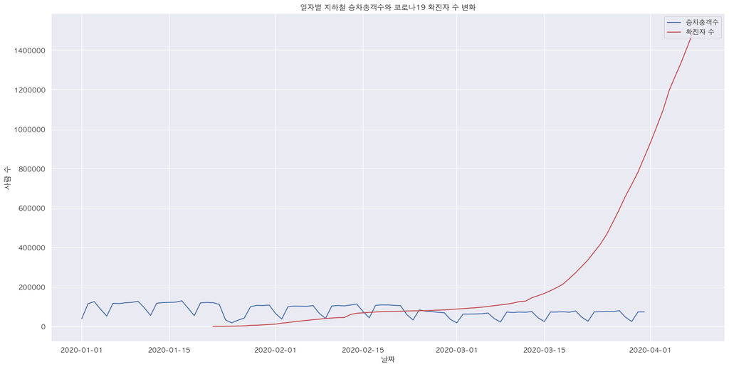

```python
x = result_df1.index
y = result_df1['승차총승객수']
y2 = result_df1['ConfirmedCases']
plt.figure(figsize=(20, 10))
plt.plot(x, y, 'b', label = '승차총객수')
plt.plot(x, y2, 'r', label = '확진자 수')
plt.title('일자별 지하철 승차총객수와 코로나19 확진자 수 변화')
plt.xlabel('날짜')
plt.ylabel('사람 수')
plt.legend(loc = 'upper right')
plt.show()
```

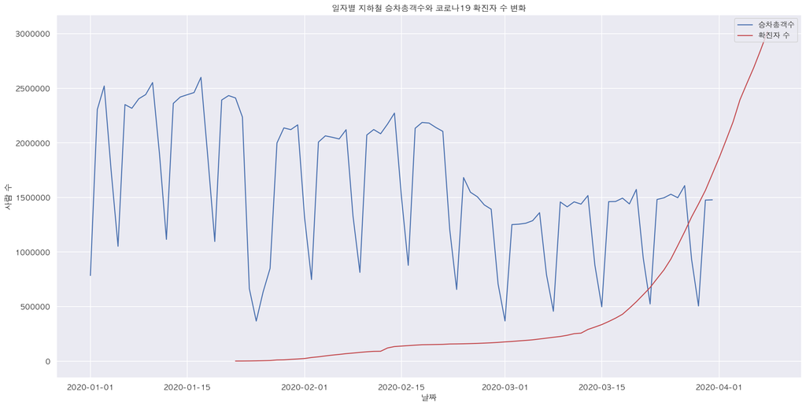

```python
x = result_df1.index
y = result_df1['승차총승객수'] * 20 # 비교를 위해 상수를 곱해줌
y2 = result_df1['ConfirmedCases'] * 2
plt.figure(figsize=(20,10))
plt.plot(x, y, 'b', label = '승차총객수')
plt.plot(x, y2, 'r', label = '확진자 수')
plt.title('일자별 지하철 승차총객수와 코로나19 확진자 수 변화')
plt.xlabel('날짜')
plt.ylabel('사람 수')
plt.legend(loc = 'upper right')
plt.show()
```

- 전 세계 확진자 수가 증가할수록 강남역 지하철 승차총객수가 평균적으로 줄어들고 있는 것을 볼 수 있다.

### 한국 확진자 수와 강남역 승차총승객수 간 비교

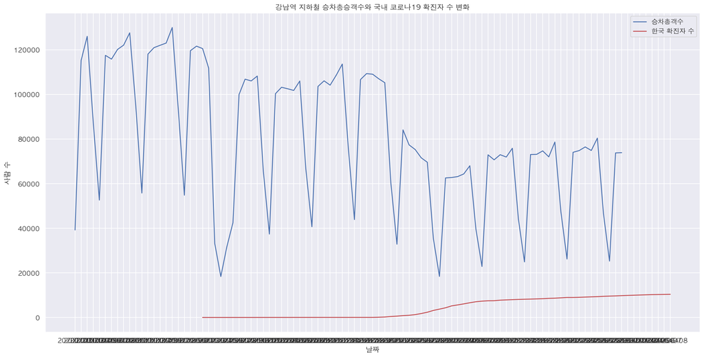

```python
covid19_korea_confirmedcase = covid19_df[['일자', 'ConfirmedCases']][covid19_df['Country_Region'] == 'Korea, South']
covid19_korea_confirmedcase.rename(columns={"ConfirmedCases":"KorConfirmed"}, inplace=True)
result_df = subway_result.merge(covid19_korea_confirmedcase, how="outer")
result_df

x = result_df['일자']
y = result_df['승차총승객수']
y2 = result_df['KorConfirmed']
plt.figure(figsize=(20,10))
plt.plot(x, y, 'b', label = '승차총객수')
plt.plot(x, y2, 'r', label = '한국 확진자 수')
plt.title('강남역 지하철 승차총승객수와 국내 코로나19 확진자 수 변화')
plt.xlabel('날짜')
plt.ylabel('사람 수')
plt.legend(loc = 'upper right')
plt.show()
```

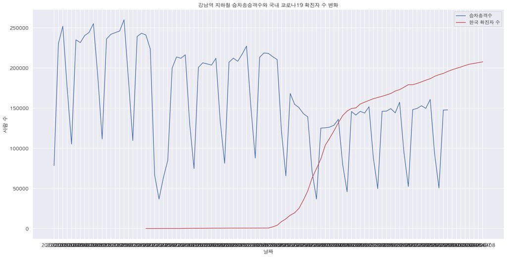

```python
covid19_korea_confirmedcase = covid19_df[['일자', 'ConfirmedCases']][covid19_df['Country_Region'] == 'Korea, South']
covid19_korea_confirmedcase.rename(columns={"ConfirmedCases":"KorConfirmed"}, inplace=True)
result_df = subway_result.merge(covid19_korea_confirmedcase, how="outer")
result_df

x = result_df['일자']
y = result_df['승차총승객수'] * 2 # 비교를 위해 상수를 곱해줌
y2 = result_df['KorConfirmed'] * 20 # 비교를 위해 상수를 곱해줌
plt.figure(figsize=(20,10))
plt.plot(x, y, 'b', label = '승차총객수')
plt.plot(x, y2, 'r', label = '한국 확진자 수')
plt.title('강남역 지하철 승차총승객수와 국내 코로나19 확진자 수 변화')
plt.xlabel('날짜')
plt.ylabel('사람 수')
plt.legend(loc = 'upper right')
plt.show()
```

- 역시 마찬가지로 국내 코로나19 확진자 수가 늘어날수록 강남역 지하철 승차총승객수가 평균적으로 줄어드는 것을 볼 수 있다.

### 4-2) 코로나19와 날씨 간의 상관관계 분석

### 한국 내 평균기온(화씨)과 확진자 수 변화 추이

- 확진자 수에 미치는 변수는 무수히 많음. 여기서는 흐름을 보는 정도에 의미를 두고 비교.
- 겨울에서 여름이 다가올수록 코로나19 확진자 수가 줄어들 것이다는 가설에 따르면 기온이 올라갈수록 확진자 수 증가폭이 줄어들어야 함.

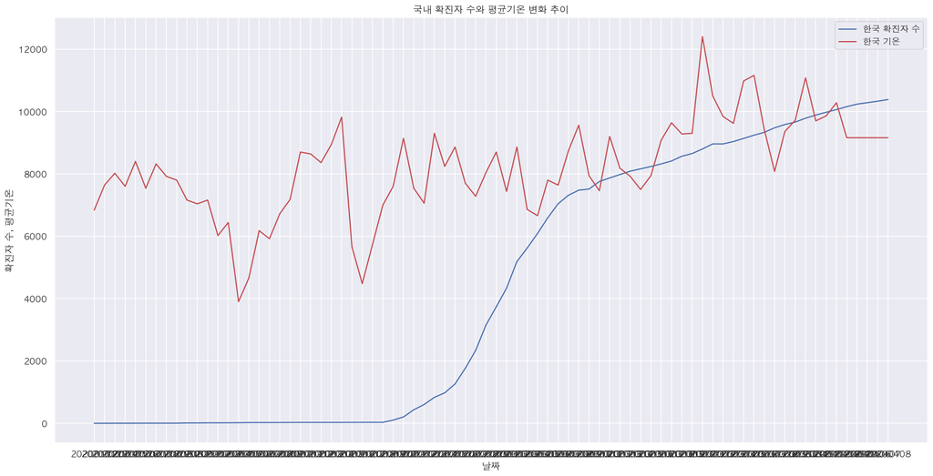

```python
covid19_korea_temp = covid19_df[['일자', 'ConfirmedCases', 'temp']][covid19_df['Country_Region'] == 'Korea, South']
covid19_korea_temp

x = covid19_korea_temp['일자']
y = covid19_korea_temp['ConfirmedCases']
y2 = covid19_korea_temp['temp'] * 200 # 비교를 위해 상수를 곱함
plt.figure(figsize=(20,10))
plt.plot(x, y, 'b', label = '한국 확진자 수')
plt.plot(x, y2, 'r', label = '한국 기온')
plt.title('국내 확진자 수와 평균기온 변화 추이')
plt.xlabel('날짜')
plt.ylabel('확진자 수, 평균기온')
plt.legend(loc = 'upper right')
plt.show()
```

- 국내 평균 기온이 올라갈수록 국내 코로나19 확진자 수 증가폭이 줄어드는 것을 볼 수 있다.

### 북반구, 남반구 비교

- 1월에서 3월, 북반구는 주로 겨울이고 남반구는 여름
- 코로나19가 열에 약하다는 가설에 따르면 남반구보다 북반구에서 더 많은 확진자가 나와야 함.

```python
import folium
m = folium.Map(location=[0.0000, 0.0000], zoom_start=2)

for item in df_country_total.index:
    lat = df_country_total['Lat'].loc[item]
    long = df_country_total['Long'].loc[item]
    folium.CircleMarker([lat, long],
                        radius = df_country_total['ConfirmedCases'].loc[item] / 2000,
                        popup = df_country_total['Country_Region'].loc[item],
                        color = 'blue',
                        fill = True).add_to(m)
m
```

[interactive chart not shown]

- 주로 북반구에서 다수의 확진자가 발생한 것을 확인할 수 있다.